# Journal mean citedness and the citation counts of individual works

A descriptive analysis of works by FORRT contributors

Author

Lukas Röseler

Published

August 13, 2026

## Abstract

Journal-level citation metrics are often read as a guide to how much attention an individual paper will get. This report checks how closely the two track, using the published output of contributors to FORRT, the Framework for Open and Reproducible Research Training. Starting from 501 ORCID iDs, 30,095 unique works were retrieved from OpenAlex and deduplicated across shared authorships. Within an individual researcher’s own journal articles, the rank correlation between a journal’s 2-year mean citedness and the citations of the specific article was positive but moderate, with a median of 0.44 across 255 researchers. Works listed on FORRT’s own publication page were more cited than the same contributors’ other recent works, by a factor of about 6.3, though most of that gap is accounted for by publication venue, contributor count, and time since publication.

## 1 Introduction

A journal’s average citation rate is frequently used as a stand-in for the likely impact of a single article published in it. The practice is long criticised (American Society for Cell Biology and others, 2013; Seglen, 1997), but it persists in hiring, promotion, and funding decisions. The question this report addresses is narrow and empirical: inside one researcher’s own body of work, how well does the average citedness of the journals they publish in predict how often each of their specific papers is cited?

The analysis uses FORRT contributors as a convenient, publicly documented sample of active researchers (FORRT (Framework for Open and Reproducible Research Training), 2026). It is descriptive. It does not evaluate anyone’s research, and it is not an assessment of FORRT. This report accompanies CITED_ (Röseler, 2026b), a small browser game built on the same data, in which players try to guess a paper’s citation count when shown only its journal’s mean citedness.

## 2 Methods

### 2.1 Data sources

Contributors were taken from FORRT’s contributor table, a CSV of 1,446 person-by-project rows covering 73 projects, published in the FORRT website repository under CC BY-NC-SA 4.0 (FORRT (Framework for Open and Reproducible Research Training), 2026). Bibliographic data came from OpenAlex (Priem et al., 2022), retrieved on 2026-08-12.

Two FORRT lists need to be kept apart. The **projects** listing names 73 projects, each with a page on forrt.org but no DOI, so project membership cannot be mapped onto specific publications. The separate **publications** list does carry DOIs, and that list is what defines a work as FORRT-listed here. No attempt was made to match the 73 projects to outputs.

### 2.2 ORCID handling

ORCID values in the contributor table are inconsistently formatted. Some are bare identifiers and many carry a full `https://orcid.org/` prefix, with one leading slash. After stripping the scheme, host, and slashes, there were 501 valid unique ORCID iDs. A further 6 values could not be repaired, such as identifiers missing a digit, and 189 named contributors have no ORCID at all. Those contributors are absent from this analysis, which is a coverage limit rather than a judgement about them. The full audit trail is in `data/orcid_normalization.csv`.

### 2.3 Retrieval

FORRT’s publication list yielded 23 distinct DOIs, of which 21 resolved in OpenAlex. The 2 that did not are a preprint and an article in a very new journal, neither indexed at the time of retrieval. Of the resolved works, 14 are journal articles and the rest are preprints.

### 2.4 Eligibility

A work was eligible when it sat in a source of type journal, that journal had a 2-year mean citedness, the work was typed as an article, and its citation count was present. Restricting to journals is necessary rather than cosmetic: OpenAlex also reports a 2-year mean citedness for repositories and book platforms, and 8,065 of the retrieved works sit in repositories. Including those would mean comparing a paper against the average citedness of a preprint server.

Table 1: Works remaining after each eligibility step, for the correlation analysis.

| Step | Works remaining |
| --- | --- |
| All unique works retrieved | 30,095 |
| In a journal source (excludes repositories, book platforms) | 13,475 |
| Journal has a 2-year mean citedness | 13,475 |
| Work type is article | 12,179 |
| Citation count present | 12,179 |
| Published 2000 to 2023 | 8,986 |

Two publication windows are used. The correlation analysis is restricted to 2000 to 2023, because a journal’s current 2-year metric is a poor comparison for works published decades earlier, and works from the last two years have had little time to accrue citations. The FORRT comparison uses 2019 onward, because FORRT’s own outputs only exist from then, and applying the earlier window would discard most of them.

### 2.5 Analysis

For each researcher, Spearman’s rho was computed between the 2-year mean citedness of the journal each of their articles appeared in and that article’s own citation count. A researcher was included when they had at least 10 eligible works in at least 5 distinct journals. The requirement on distinct journals matters more than the one on works, because mean citedness is a single value per journal, so a researcher publishing repeatedly in a few journals produces a correlation built almost entirely on ties. Works with zero citations were kept, since dropping them would select on the outcome.

The FORRT comparison is within researcher. For every contributor holding at least one FORRT-listed eligible work and at least one other eligible work of their own, the contrast is the log ratio of the median citations of the two sets. This is tested across contributors with a Wilcoxon signed-rank test, with a bootstrap interval on the median. A negative binomial regression then estimates citations from FORRT listing, contributor count, journal mean citedness, and time since publication. Poisson was fitted first only to check dispersion. Standard errors are clustered on journal, since works in the same journal share the journal predictor. Analysis code is in `scripts/analyse.py`.

## 3 Results

### 3.1 The corpus

The retrieved corpus covers 30,095 unique works. Citation counts are heavily right-skewed and many works have none, which is typical and is why the models below use rank and count methods rather than ordinary regression.

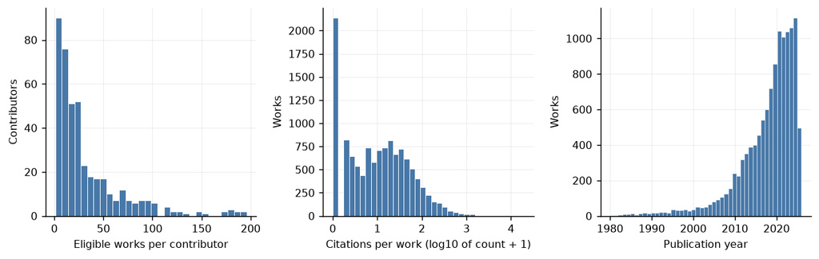

Figure 1: Left: works per contributor among eligible articles. Centre: citations per work, log scale, zero-citation works shown in the leftmost bin. Right: eligible articles by publication year.

### 3.2 How well journal mean citedness tracks individual citations

255 of the 501 contributors met the inclusion criteria. The median correlation was 0.44, with an interquartile range of 0.29 to 0.61. 96 percent of researchers (245 of 255) had a positive correlation, p < .001.

So the relationship is real and consistently positive in direction, but moderate in size. A median rho near 0.44 means journal mean citedness orders a researcher’s own papers by citation count considerably better than chance and considerably worse than reliably.

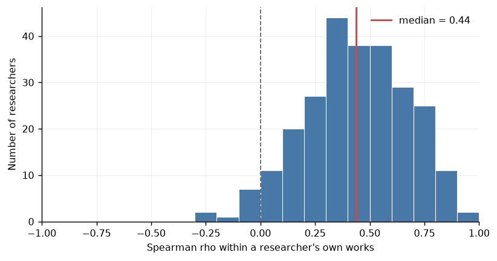

Figure 2: Distribution across researchers of the within-researcher rank correlation between journal mean citedness and the citation count of the individual article.

### 3.3 FORRT-listed works compared with contributors’ other works

192 contributors had both at least one FORRT-listed eligible article and at least one other eligible article of their own from 2019 onward. Their FORRT-listed works were more cited than their own other works by a median factor of 6.3 (bootstrap 95 percent interval 4.8 to 7.7). 84 percent of contributors (161 of 192) showed the gap in that direction, p < .001.

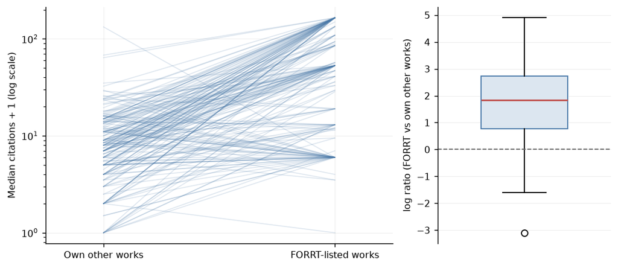

Figure 3: Left: each faint line is one contributor, joining the median citations of their own non-listed works to the median of their FORRT-listed works. Right: distribution of the within-contributor log ratios, with zero marking no difference.

That unadjusted gap mixes several things together, so the regression separates them. It uses the 3,512 eligible articles belonging to these contributors, of which 14 are FORRT-listed, across 1,261 journals. The Poisson dispersion statistic was 66, far above 1, which is why a negative binomial model is reported.

Table 2: Negative binomial model of citation counts. Values are incidence rate ratios with 95 percent confidence intervals, standard errors clustered on journal.

| Predictor | IRR (95% CI) | p |
| --- | --- | --- |
| Intercept | 0.08 (0.06 to 0.10) | < .001 |
| On FORRT publication list | 1.77 (1.20 to 2.60) | .004 |
| Number of contributors (log) | 1.39 (1.31 to 1.48) | < .001 |
| Journal mean citedness (log) | 3.13 (2.74 to 3.59) | < .001 |
| Years since publication (log) | 8.67 (7.68 to 9.77) | < .001 |

Reading the table, and expressing the logged predictors per doubling rather than per log unit: doubling a journal’s mean citedness is associated with about 2.21 times the citations, doubling the number of contributors with about 1.26 times, and doubling the time since publication with about 4.47 times. Being on FORRT’s publication list is associated with about 1.77 times the citations once venue, contributor count, and age are held constant.

The comparison between that adjusted figure and the raw factor of 6.3 is the main point of this section. Most of the apparent citation advantage of FORRT-listed works is not specific to their being FORRT outputs. It follows from their being recent, having many contributors, and appearing in higher-citedness journals. Removing contributor count from the model raises the FORRT coefficient to 2.61, which shows how much of it travels with author count.

Collinearity was checked rather than assumed. The correlation between FORRT listing and log contributor count is 0.08, and no predictor had a variance inflation factor above 1.07, so the two can sit in the same model. Excluding works whose author list is truncated at OpenAlex’s 100-author cap leaves the FORRT estimate at about 1.87.

All of this rests on 14 distinct FORRT-listed articles, so the FORRT estimate should be read as a rough indication and not a precise effect.

## 4 Limitations

The journal metric and the citation counts do not refer to the same period. A journal’s 2-year mean citedness is a single current snapshot, while a work’s citation count is cumulative over its life. The year windows and the age covariate reduce this mismatch but do not remove it.

Coverage is incomplete. 189 named contributors have no ORCID and are missing entirely, another 6 have unusable identifiers, and 57 valid ORCIDs returned no works from OpenAlex. Works are also missed where an author’s ORCID is not attached to a record in OpenAlex.

Result 3 rests on 14 FORRT-listed articles shared among 192 contributors, so the paired contrasts are not independent of each other: the same handful of papers appears in many of them. FORRT outputs are also systematically recent and mass-authored, so FORRT membership stays entangled with publication era and contributor count even after adjustment.

More broadly, works in the same journal and works sharing authors are not independent observations. Clustering the standard errors on journal addresses part of that and not all of it. Nothing here is causal. These are associations in observational bibliographic data, and a citation count measures attention rather than quality or rigour. A correlation of this size within a researcher’s own portfolio gives no licence to use a journal metric to judge an individual paper or the person who wrote it.

## 5 Transparency statement

This analysis was designed, coded, and drafted with Claude, an AI assistant made by Anthropic, running in Claude Code. The author set the question, chose the sample and the main analytic decisions, checked the data sources and the behaviour of the OpenAlex API, and reviewed the output. Claude wrote the retrieval and analysis code and the first draft of this text.

Every number in this report is computed when the document is rendered, from the data files in this folder, rather than typed into the prose. The retrieval script and the analysis module are both in the repository, so the figures and statistics can be reproduced or corrected. Two errors found during development are worth recording, because both changed the results: an early version of the retrieval script kept only the first DOI listed for each FORRT publication, which silently selected the preprint instead of the published article for two entries and dropped one paper with over a hundred citations from the FORRT set; and the eligibility filter has to exclude repositories, because OpenAlex reports a 2-year mean citedness for them too.

## 6 Data and code availability

All files are in the `forrt-members/` folder of the CITED_ repository at https://github.com/LukasRoeseler/cited.

- `scripts/fetch_forrt_works.py` retrieves everything from FORRT and OpenAlex.
- `scripts/analyse.py` holds the analysis functions used by this report.
- `data/` holds the retrieved tables, including `works.csv`, `author_works.csv`, `sources.csv`, and the ORCID audit trail.
- `data/author_correlations.csv` holds the per-researcher correlations.

Per-researcher results are reported only in aggregate. FORRT contributors are listed publicly for contribution credit, not as participants in a study, so no file in this repository joins a person’s name or ORCID to their own correlation, and no individual is named in this report, including at the extremes of the distribution. `data/contributors.csv` retains ORCID iDs because they are needed to repeat the retrieval and are already public in FORRT’s own table, but it carries no results.

Contributor data is reused from FORRT under CC BY-NC-SA 4.0 and has been transformed for this analysis (FORRT (Framework for Open and Reproducible Research Training), 2026). OpenAlex data is CC0 (Priem et al., 2022). For a plainer discussion of why a single journal number describes a journal poorly, see Röseler (2026a).

## References

American Society for Cell Biology and others. (2013). *San francisco declaration on research assessment (DORA)*. https://sfdora.org/read/

FORRT (Framework for Open and Reproducible Research Training). (2026). *FORRT: Framework for open and reproducible research training*. https://doi.org/10.17605/OSF.IO/QBCJ3

Priem, J., Piwowar, H., & Orr, R. (2022). *OpenAlex: A fully-open index of scholarly works, authors, venues, institutions, and concepts*. https://arxiv.org/abs/2205.01833

Röseler, L. (2026a). *Bibliometrics 101: Why one number cannot describe a journal*. https://lukasroeseler.github.io/unimuenster/bibliometrics-101/index.html

Röseler, L. (2026b). *CITED_ [web-based game]*. https://lukasroeseler.github.io/cited/

Seglen, P. O. (1997). Why the impact factor of journals should not be used for evaluating research. *BMJ*, *314*(7079), 498–502. https://doi.org/10.1136/bmj.314.7079.497